# Eventos catastróficos por cuadrante-semana: inundaciones, deslizamientos y otros desastres

Cindy Carolina Lugo Rozo

2026-09-17

# Introducción

Este documento continúa el pipeline del panel **semana x cuadrante** para SAIDI/SAIFI, incorporando eventos de origen natural (inundaciones, deslizamientos, vendavales, etc.) reportados oficialmente por la Unidad Nacional para la Gestión del Riesgo de Desastres (UNGRD).

**Hipótesis:** semanas con eventos catastróficos en el municipio de un cuadrante pueden coincidir con mayor frecuencia/duración de interrupciones eléctricas (daño directo a infraestructura, caída de árboles sobre líneas, inundación de subestaciones, etc.).

**Fuente:** portal de Datos Abiertos de Colombia (`datos.gov.co`), dataset “Emergencias UNGRD” (id `wwkg-r6te`), descarga directa vía Socrata, sin necesidad de autenticación.

**Granularidad de la fuente:** los eventos se reportan a nivel **municipal**, con fecha exacta del evento — no hay coordenadas puntuales ni nivel de cuadrante. La estrategia de asignación es la misma que ya usaste para estratificación: cuadrante → municipio (mismo código DIVIPOLA). La diferencia clave es que **este dato sí varía en el tiempo** (a diferencia de estrato/infraestructura, que son estáticos): cada evento tiene una fecha, por lo que se puede agregar a nivel de semana.

**Precisión metodológica que se mantiene explícita:** un evento reportado en el municipio se asigna a **todos** los cuadrantes de ese municipio en la semana correspondiente. Esto es una limitación de granularidad idéntica a la de `estrato_predominante_municipal` — la variable resultante debe interpretarse como *“hubo un evento catastrófico reportado en el municipio del cuadrante esa semana”*, no como *“el cuadrante específico sufrió daño directo”*.

## Paquetes y carga de insumos previos

```r
options(repos = c(CRAN = "https://cloud.r-project.org"))

paquetes_desastres <- c("readr", "dplyr", "tidyr", "janitor", "lubridate",
                        "ggplot2", "knitr", "kableExtra", "scales",
                        "sf", "leaflet")

invisible(lapply(paquetes_desastres, function(p) {
  if (!requireNamespace(p, quietly = TRUE)) install.packages(p)
  library(p, character.only = TRUE)
}))
```

```r
# Misma logica que Scripts/Edwin/analisis_correlacion.Rmd.
# Este Rmd vive en Scripts/Cindy/v4/ → el .env de la raiz esta 3 niveles arriba.
env_path <- file.path("..", "..", "..", ".env")
if (file.exists(".env")) {
  readRenviron(".env")
} else if (file.exists(env_path)) {
  readRenviron(env_path)
}

UBICACION_DATA <- Sys.getenv("UBICACION_DATA")
if (UBICACION_DATA == "") {
  stop("UBICACION_DATA no esta definida. Verifica el archivo .env.")
}

cat(sprintf("UBICACION_DATA: %s\n", UBICACION_DATA))
```

```
## UBICACION_DATA: D:/OneDrive - PUJ Cali/Projecto_Grado_Javeriana/Data_Project/
```

```r
DIR_IMAGENES <- file.path(
  UBICACION_DATA, "imagenes", "desastres_naturales_cuadrantes_reales"
)
dir.create(DIR_IMAGENES, recursive = TRUE, showWarnings = FALSE)
knitr::opts_chunk$set(
  fig.path = paste0(DIR_IMAGENES, "/"),
  dev = "png"
)
```

Si vienes de continuar la sesión anterior, `data_final` y `estratificacion_cuadrante` (que ya trae `codigo_municipio` por cuadrante) existen en el entorno. Si es sesión nueva, se recargan.

```r
if (!exists("data_final")) {
  data_final <- readRDS(file.path(UBICACION_DATA, "data_final_modelo_cuadrantes_reales.rds"))
  cat("data_final recargado desde el .rds exportado.\n")
}
```

```
## data_final recargado desde el .rds exportado.
```

```r
if (!exists("estratificacion_cuadrante")) {
  ruta_estrato <- file.path(UBICACION_DATA, "estratificacion_municipal_por_cuadrante.csv")
  if (!file.exists(ruta_estrato)) {
    stop("No se encontró estratificacion_municipal_por_cuadrante.csv. ",
         "Corre primero el documento de estratificación municipal.")
  }
  estratificacion_cuadrante <- read_csv(ruta_estrato, show_col_types = FALSE)
  cat("estratificacion_cuadrante recargado desde CSV.\n")
}
```

```
## estratificacion_cuadrante recargado desde CSV.
```

```r
data_final <- data_final %>%
  mutate(id_cuadrante = as.character(id_cuadrante))

# Mapeo cuadrante -> municipio (código DIVIPOLA), ya construido en el
# documento de estratificación. Es la pieza clave para unir eventos
# municipales a cada cuadrante.
mapeo_cuadrante_municipio <- estratificacion_cuadrante %>%
  mutate(id_cuadrante = as.character(id_cuadrante)) %>%
  select(id_cuadrante, codigo_municipio, municipio) %>%
  distinct()

cat(sprintf("Cuadrantes con municipio asignado: %d\n", nrow(mapeo_cuadrante_municipio)))
```

```
## Cuadrantes con municipio asignado: 344
```

# Parte 1 — Descarga del dataset UNGRD

```r
URL_UNGRD    <- "https://www.datos.gov.co/api/views/wwkg-r6te/rows.csv?accessType=DOWNLOAD"
ARCHIVO_UNGRD <- file.path(UBICACION_DATA, "emergencias_ungrd.csv")

if (!file.exists(ARCHIVO_UNGRD)) {
  message("Descargando dataset UNGRD (puede tardar, el archivo nacional es grande)...")
  download.file(URL_UNGRD, destfile = ARCHIVO_UNGRD, mode = "wb")
  message("Descarga completada.")
} else {
  message("Dataset UNGRD ya disponible localmente: ", ARCHIVO_UNGRD)
}

emergencias_raw <- read_csv(ARCHIVO_UNGRD, show_col_types = FALSE) %>%
  clean_names()

cat(sprintf("Registros nacionales totales: %d\n", nrow(emergencias_raw)))
```

```
## Registros nacionales totales: 25857
```

```r
cat("Columnas disponibles:\n")
```

```
## Columnas disponibles:
```

```r
print(names(emergencias_raw))
```

```
##  [1] "fecha"
##  [2] "departamento"
##  [3] "municipio"
##  [4] "evento"
##  [5] "divipola"
##  [6] "fallecidos"
##  [7] "heridos"
##  [8] "desaparecidos"
##  [9] "personas"
## [10] "familias"
## [11] "viviendas_destruidas"
## [12] "viviendas_averiadas"
## [13] "vias_averiadas"
## [14] "puentes_vehiculares"
## [15] "puentes_peatonales"
```

[output cut: 56 more lines]

## Filtrar Norte de Santander y eventos de interés

Se excluyen deliberadamente eventos como accidentes de tránsito, mineros o explosiones — no son la hipótesis de esta tesis (riesgo climático/geológico sobre la red eléctrica), aunque estén en la misma fuente.

```r
eventos_relevantes <- c(
  "INUNDACION", "MOVIMIENTO EN MASA", "VENDAVAL", "GRANIZADA",
  "AVENIDA TORRENCIAL", "CRECIENTE SUBITA", "EROSION", "SISMO",
  "TEMPORAL", "TORMENTA ELECTRICA", "DESLIZAMIENTO", "INCENDIO DE COBERTURA VEGETAL"
)

emergencias_nds <- emergencias_raw %>%
  filter(
    departamento == "NORTE DE SANTANDER",
    evento %in% eventos_relevantes
  ) %>%
  mutate(
    fecha        = as.Date(fecha, format = "%m/%d/%Y"),
    divipola     = as.character(divipola)
  )

cat(sprintf("Eventos filtrados en Norte de Santander: %d\n", nrow(emergencias_nds)))
```

```
## Eventos filtrados en Norte de Santander: 1326
```

```r
kable(
  emergencias_nds %>% count(evento, sort = TRUE, name = "n_eventos"),
  caption = "Distribución de eventos catastróficos filtrados — Norte de Santander"
) %>%
  kable_styling(bootstrap_options = c("striped", "condensed"), full_width = FALSE)
```

Distribución de eventos catastróficos filtrados — Norte de Santander

| evento | n_eventos |
| --- | --- |
| MOVIMIENTO EN MASA | 645 |
| INCENDIO DE COBERTURA VEGETAL | 242 |
| INUNDACION | 209 |
| AVENIDA TORRENCIAL | 76 |
| CRECIENTE SUBITA | 73 |
| VENDAVAL | 60 |
| TEMPORAL | 10 |
| GRANIZADA | 6 |
| EROSION | 3 |
| SISMO | 1 |
| TORMENTA ELECTRICA | 1 |

## Validación: cobertura temporal de la fuente

```r
rango_ungrd <- emergencias_nds %>%
  summarise(fecha_min = min(fecha, na.rm = TRUE), fecha_max = max(fecha, na.rm = TRUE))

rango_panel <- data_final %>%
  summarise(fecha_min = min(semana, na.rm = TRUE), fecha_max = max(semana, na.rm = TRUE))

cat(sprintf("Rango UNGRD (Norte de Santander): %s a %s\n",
            rango_ungrd$fecha_min, rango_ungrd$fecha_max))
```

```
## Rango UNGRD (Norte de Santander): 2019-01-06 a 2022-12-21
```

```r
cat(sprintf("Rango del panel (data_final): %s a %s\n",
            rango_panel$fecha_min, rango_panel$fecha_max))
```

```
## Rango del panel (data_final): 2024-01-01 a 2025-12-29
```

```r
if (rango_ungrd$fecha_max < rango_panel$fecha_min | rango_ungrd$fecha_min > rango_panel$fecha_max) {
  warning("Los rangos de fechas de UNGRD y del panel no se superponen. Revisar antes de continuar.")
} else {
  cat("Los rangos se superponen: la union aportara informacion en parte del periodo.\n")
}
```

## Validación: municipios sin correspondencia DIVIPOLA

```r
municipios_ungrd    <- unique(emergencias_nds$divipola)
municipios_panel     <- unique(mapeo_cuadrante_municipio$codigo_municipio)

solo_en_ungrd  <- setdiff(municipios_ungrd, municipios_panel)
solo_en_panel  <- setdiff(municipios_panel, municipios_ungrd)

cat(sprintf("Municipios con eventos UNGRD pero sin cuadrantes en el panel: %d\n", length(solo_en_ungrd)))
```

```
## Municipios con eventos UNGRD pero sin cuadrantes en el panel: 2
```

```r
cat(sprintf("Municipios con cuadrantes en el panel pero sin eventos UNGRD registrados: %d\n", length(solo_en_panel)))
```

```
## Municipios con cuadrantes en el panel pero sin eventos UNGRD registrados: 18
```

```r
if (length(solo_en_panel) > 0) {
  cat("Municipios del panel sin eventos registrados (puede ser normal si no tuvieron emergencias):\n")
  print(
    estratificacion_cuadrante %>%
      filter(codigo_municipio %in% solo_en_panel) %>%
      distinct(codigo_municipio, municipio)
  )
}
```

```
## Municipios del panel sin eventos registrados (puede ser normal si no tuvieron emergencias):
## # A tibble: 18 × 2
##    codigo_municipio municipio
##               <dbl> <chr>
##  1            15223 CUBARÁ
##  2            13473 MORALES
##  3            20614 RÍO DE ORO
##  4            20011 AGUACHICA
##  5            13600 RIOVIEJO
##  6            20383 LA GLORIA
##  7            68162 CERRITO
##  8            68867 VETAS
##  9            68255 EL PLAYÓN
## 10            20710 SAN ALBERTO
## 11            20770 SAN MARTÍN
## 12            68575 PUERTO WILCHES
## 13            20295 GAMARRA
## 14            20310 GONZALEZ
## 15            13042 ARENAL
## 16               NA <NA>
## 17            20550 PELAYA
## 18            20517 PAILITAS
```

# Parte 2 — Agregación semanal por municipio

Se agrega el conteo y tipo de eventos a nivel de **municipio-semana**, alineando la semana con la misma grilla temporal usada en el resto del panel (`data_final$semana`).

```r
# Grilla de semanas del panel (mismo ancla temporal que el resto del pipeline)
semanas_panel <- data_final %>%
  distinct(semana) %>%
  arrange(semana)

# Se asigna cada evento a la semana del panel más cercana (hacia atrás),
# replicando la misma lógica de alineación usada para NDVI/población.
asignar_semana_panel <- function(fecha_evento, semanas) {
  semanas[which.max(semanas[semanas <= fecha_evento])]
}

emergencias_nds <- emergencias_nds %>%
  rowwise() %>%
  mutate(
    semana = if (any(semanas_panel$semana <= fecha)) {
      max(semanas_panel$semana[semanas_panel$semana <= fecha])
    } else {
      NA_real_
    }
  ) %>%
  ungroup() %>%
  mutate(semana = as.Date(semana, origin = "1970-01-01"))

cat(sprintf("Eventos sin semana asignable (fuera del rango del panel): %d\n",
            sum(is.na(emergencias_nds$semana))))
```

```
## Eventos sin semana asignable (fuera del rango del panel): 1326
```

```r
# Conteo de eventos por municipio-semana, con desagregación por tipo
eventos_municipio_semana <- emergencias_nds %>%
  filter(!is.na(semana)) %>%
  group_by(divipola, municipio, semana) %>%
  summarise(
    n_eventos_catastroficos = n(),
    tipos_evento            = paste(sort(unique(evento)), collapse = "; "),
    personas_afectadas_evt  = sum(personas, na.rm = TRUE),
    familias_afectadas_evt  = sum(familias, na.rm = TRUE),
    hubo_inundacion         = as.integer(any(evento == "INUNDACION")),
    hubo_movimiento_masa    = as.integer(any(evento == "MOVIMIENTO EN MASA")),
    hubo_vendaval           = as.integer(any(evento == "VENDAVAL")),
    .groups = "drop"
  )

cat(sprintf("Municipio-semanas con al menos un evento: %d\n", nrow(eventos_municipio_semana)))
```

```
## Municipio-semanas con al menos un evento: 0
```

```r
kable(head(eventos_municipio_semana, 10),
      caption = "Vista previa — eventos catastróficos agregados por municipio-semana") %>%
  kable_styling(bootstrap_options = c("striped", "condensed"), font_size = 9)
```

Vista previa — eventos catastróficos agregados por municipio-semana

[output not shown]

# Parte 3 — Expansión a cuadrante-semana

Cada municipio-semana con eventos se replica a **todos** los cuadrantes que pertenecen a ese municipio, generando la tabla final lista para unir a `data_final`.

```r
desastres_cuadrante_semana <- mapeo_cuadrante_municipio %>%
  rename(divipola = codigo_municipio) %>%
  mutate(divipola = as.character(divipola)) %>%
  left_join(
    eventos_municipio_semana %>%
      mutate(divipola = as.character(divipola)) %>%
      select(-municipio),
    by = "divipola"
  ) %>%
  select(-divipola)

cat(sprintf(
  "Tabla expandida a cuadrante-semana: %d filas (cuadrantes con al menos un evento en alguna semana)\n",
  sum(!is.na(desastres_cuadrante_semana$n_eventos_catastroficos))
))
```

```
## Tabla expandida a cuadrante-semana: 0 filas (cuadrantes con al menos un evento en alguna semana)
```

# Parte 4 — Análisis exploratorio y gráficos

## Frecuencia de eventos por tipo (Norte de Santander, todo el período)

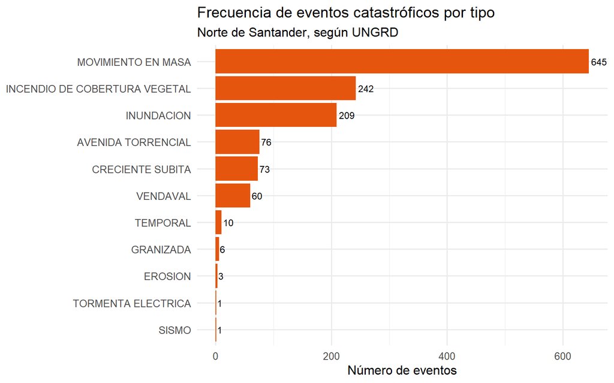

```r
emergencias_nds %>%
  count(evento, sort = TRUE) %>%
  ggplot(aes(x = reorder(evento, n), y = n)) +
  geom_col(fill = "#e6550d") +
  geom_text(aes(label = n), hjust = -0.15, size = 3.2) +
  coord_flip() +
  labs(
    title = "Frecuencia de eventos catastróficos por tipo",
    subtitle = "Norte de Santander, según UNGRD",
    x = NULL, y = "Número de eventos"
  ) +
  theme_minimal(base_size = 12)
```

## Serie temporal de eventos por semana

[figure not shown]

```r
eventos_municipio_semana %>%
  group_by(semana) %>%
  summarise(n_eventos = sum(n_eventos_catastroficos), .groups = "drop") %>%
  ggplot(aes(x = semana, y = n_eventos)) +
  geom_col(fill = "#3182bd") +
  labs(
    title = "Eventos catastróficos por semana — Norte de Santander",
    subtitle = "Suma de todos los municipios",
    x = NULL, y = "N° de eventos"
  ) +
  theme_minimal(base_size = 12)
```

## Municipios más afectados

[figure not shown]

```r
eventos_municipio_semana %>%
  group_by(municipio) %>%
  summarise(n_eventos = sum(n_eventos_catastroficos), .groups = "drop") %>%
  slice_max(n_eventos, n = 15) %>%
  ggplot(aes(x = reorder(municipio, n_eventos), y = n_eventos)) +
  geom_col(fill = "#31a354") +
  coord_flip() +
  labs(
    title = "Municipios con más eventos catastróficos reportados",
    subtitle = "Top 15 — todo el período disponible",
    x = NULL, y = "N° de eventos"
  ) +
  theme_minimal(base_size = 12)
```

## Mapa: cuadrantes según número de eventos históricos en su municipio

Requiere `cuadrantes_infra` (geometría real) del documento de infraestructura. Si no está en el entorno, este chunk se omite sin romper el knit.

```r
if (exists("cuadrantes_infra")) {

  eventos_totales_municipio <- eventos_municipio_semana %>%
    group_by(municipio) %>%
    summarise(n_eventos_total = sum(n_eventos_catastroficos), .groups = "drop")

  mapa_desastres_datos <- cuadrantes_infra %>%
    mutate(id_cuadrante = as.character(if ("id_cuadrante" %in% names(.)) id_cuadrante else CUADRANTE)) %>%
    left_join(mapeo_cuadrante_municipio, by = "id_cuadrante") %>%
    left_join(eventos_totales_municipio, by = "municipio") %>%
    st_transform(4326)

  pal_desastres <- colorNumeric("OrRd", domain = mapa_desastres_datos$n_eventos_total, na.color = "grey80")

  leaflet(mapa_desastres_datos) %>%
    addProviderTiles(providers$CartoDB.Positron) %>%
    addPolygons(
      fillColor = ~pal_desastres(n_eventos_total),
      fillOpacity = 0.65, color = "gray40", weight = 0.6, opacity = 0.8,
      label = ~paste0("Cuadrante ", id_cuadrante, " — ", municipio,
                      ": ", n_eventos_total, " eventos históricos")
    ) %>%
    addLegend(pal = pal_desastres, values = ~n_eventos_total,
              title = "N° eventos\nhistóricos\n(municipio)", position = "bottomright")

} else {
  message("cuadrantes_infra no está en el entorno — se omite el mapa. Corre primero el documento de infraestructura.")
}
```

# Parte 5 — Integración al panel

```r
data_final <- data_final %>%
  select(-any_of(c("n_eventos_catastroficos", "tipos_evento",
                    "personas_afectadas_evt", "familias_afectadas_evt",
                    "hubo_inundacion", "hubo_movimiento_masa", "hubo_vendaval"))) %>%
  left_join(
    desastres_cuadrante_semana %>%
      select(id_cuadrante, semana, n_eventos_catastroficos, tipos_evento,
             personas_afectadas_evt, familias_afectadas_evt,
             hubo_inundacion, hubo_movimiento_masa, hubo_vendaval),
    by = c("id_cuadrante", "semana")
  ) %>%
  mutate(
    # NA significa "sin evento registrado esa semana", no dato faltante:
    # se recodifica explícitamente a 0 para las variables de conteo/binarias
    n_eventos_catastroficos = replace_na(n_eventos_catastroficos, 0),
    hubo_inundacion         = replace_na(hubo_inundacion, 0L),
    hubo_movimiento_masa    = replace_na(hubo_movimiento_masa, 0L),
    hubo_vendaval           = replace_na(hubo_vendaval, 0L),
    hubo_evento_catastrofico = as.integer(n_eventos_catastroficos > 0)
  )

cat(sprintf("Panel actualizado: %d filas x %d columnas\n", nrow(data_final), ncol(data_final)))
```

```
## Panel actualizado: 36120 filas x 108 columnas
```

```r
cobertura_desastres <- data_final %>%
  summarise(
    filas_total                  = n(),
    semanas_con_evento            = sum(hubo_evento_catastrofico),
    pct_semanas_con_evento         = round(100 * mean(hubo_evento_catastrofico), 2)
  )

kable(t(cobertura_desastres), col.names = "Valor",
      caption = "Cobertura de eventos catastróficos en el panel") %>%
  kable_styling(bootstrap_options = c("striped"), full_width = FALSE)
```

Cobertura de eventos catastróficos en el panel

|  | Valor |
| --- | --- |
| filas_total | 36120 |
| semanas_con_evento | 0 |
| pct_semanas_con_evento | 0 |

## SAIDI/SAIFI en semanas con vs. sin evento catastrófico

Condicional: solo corre si `SAIDI`/`SAIFI` ya están en `data_final`.

```r
if (all(c("SAIDI", "SAIFI") %in% names(data_final))) {

  datos_plot <- data_final %>%
    filter(hubo_falla == 1) %>%
    mutate(evento_f = factor(
      hubo_evento_catastrofico,
      levels = c(0, 1),
      labels = c("Sin evento", "Con evento")
    ))

  cat("Distribución de evento_f en semanas con falla:\n")
  print(table(datos_plot$evento_f, useNA = "ifany"))

  if (n_distinct(datos_plot$evento_f) < 2) {
    message("Solo hay un nivel de evento_f en las semanas con falla — no se puede comparar. Se omite el gráfico.")
  } else {

    datos_plot %>%
      tidyr::pivot_longer(c(SAIDI, SAIFI), names_to = "indicador", values_to = "valor") %>%
      ggplot(aes(x = evento_f, y = valor, fill = evento_f)) +
      geom_boxplot(outlier.alpha = 0.2, width = 0.5) +
      facet_wrap(~indicador, scales = "free_y") +
      scale_fill_manual(values = c("Sin evento" = "#a1d99b", "Con evento" = "#de2d26")) +
      labs(
        title = "SAIDI/SAIFI según ocurrencia de evento catastrófico en el municipio",
        subtitle = "Solo semanas con falla eléctrica registrada",
        x = NULL, y = "Valor"
      ) +
      theme_minimal(base_size = 12) +
      theme(legend.position = "none")
  }

} else {
  message("SAIDI/SAIFI no están en data_final todavía — se omite este gráfico.")
}
```

```
## Distribución de evento_f en semanas con falla:
##
## Sin evento Con evento
##      13351          0
```

# Parte 6 — Exportaciones

```r
write_csv(
  eventos_municipio_semana,
  file.path(UBICACION_DATA, "eventos_catastroficos_municipio_semana.csv")
)

write_csv(
  desastres_cuadrante_semana,
  file.path(UBICACION_DATA, "eventos_catastroficos_cuadrante_semana.csv")
)

saveRDS(data_final, file.path(UBICACION_DATA, "data_final_modelo_cuadrantes_reales.rds"))
write_csv(data_final, file.path(UBICACION_DATA, "data_final_modelo_cuadrantes_reales.csv"))

cat(sprintf("Panel final guardado: %d filas x %d columnas (incluye eventos catastróficos)\n",
            nrow(data_final), ncol(data_final)))
```

```
## Panel final guardado: 36120 filas x 108 columnas (incluye eventos catastróficos)
```

# Parte 7 — Sismos (pendiente: fuente por confirmar)

El dataset UNGRD usado arriba prácticamente no reporta sismos (son manejados aparte por el Servicio Geológico Colombiano). Cuando tengas el enlace de descarga directa del catálogo de sismicidad del SGC (`datos.sgc.gov.co` o `sish.sgc.gov.co`), esta sección se completa con la misma estructura: descarga → filtro geográfico (Norte de Santander, por bounding box de coordenadas ya que sismos sí traen lat/lon propias) → agregación semanal → unión al panel.

**Diferencia clave esperada con sismos:** a diferencia de los eventos UNGRD (asignados por municipio), el catálogo del SGC trae epicentro como punto (lat/lon) — por lo tanto la asignación a cuadrante puede hacerse por **distancia real** del epicentro al centroide de cada cuadrante (`centroides_cuadrante_real`), no por pertenencia municipal. Esto sería más preciso que el resto de variables de esta sección, y permitiría además ponderar por magnitud/distancia (p. ej. energía sísmica atenuada con la distancia) en vez de un simple binario.

```r
# ============================================================
# PENDIENTE: completar cuando se tenga la URL de descarga del SGC
# ============================================================
#
# URL_SGC <- "..."  # pendiente
#
# sismos_raw <- read_csv(URL_SGC) %>% clean_names()
#
# sismos_nds <- sismos_raw %>%
#   filter(
#     latitud  >= 7.0, latitud  <= 9.5,   # bounding box aproximado N. de Santander
#     longitud >= -73.5, longitud <= -72.0
#   )
#
# Asignación por distancia al centroide real (no por municipio):
# library(sf)
# sismos_sf <- st_as_sf(sismos_nds, coords = c("longitud", "latitud"), crs = 4326)
# centroides_sf <- centroides_cuadrante_real %>%
#   st_as_sf(coords = c("lon", "lat"), crs = 4326, remove = FALSE)
#
# Para cada sismo, cuadrante más cercano (o todos los cuadrantes dentro
# de un radio de influencia, ponderado por magnitud/distancia):
# sismos_cercanos <- st_join(sismos_sf, centroides_sf, join = st_nearest_feature)
```

# Diccionario de variables incorporadas

```r
tribble(
  ~Variable, ~Tipo, ~Variacion, ~Fuente, ~Descripcion,

  "n_eventos_catastroficos", "Numérica (conteo)", "Cuadrante x semana", "UNGRD",
    "Número de eventos catastróficos (inundación, movimiento en masa, vendaval, etc.) reportados en el MUNICIPIO del cuadrante, en esa semana. Un evento municipal se replica a todos los cuadrantes del municipio.",

  "hubo_evento_catastrofico", "Binaria", "Cuadrante x semana", "Derivada",
    "1 si n_eventos_catastroficos > 0 esa semana.",

  "hubo_inundacion", "Binaria", "Cuadrante x semana", "UNGRD",
    "1 si hubo al menos un evento de tipo INUNDACION en el municipio esa semana.",

  "hubo_movimiento_masa", "Binaria", "Cuadrante x semana", "UNGRD",
    "1 si hubo al menos un evento de tipo MOVIMIENTO EN MASA (deslizamiento) en el municipio esa semana.",

  "hubo_vendaval", "Binaria", "Cuadrante x semana", "UNGRD",
    "1 si hubo al menos un evento de tipo VENDAVAL en el municipio esa semana.",

  "personas_afectadas_evt", "Numérica", "Cuadrante x semana", "UNGRD",
    "Suma de personas afectadas por los eventos catastróficos del municipio esa semana (variable municipal, no específica del cuadrante).",

  "tipos_evento", "Texto", "Cuadrante x semana", "UNGRD",
    "Lista de tipos de evento distintos ocurridos esa semana en el municipio, separados por punto y coma."
) %>%
  kable(caption = "Diccionario — variables de eventos catastróficos") %>%
  kable_styling(bootstrap_options = c("striped", "hover", "condensed")) %>%
  column_spec(5, width = "42%")
```

Diccionario — variables de eventos catastróficos

| Variable | Tipo | Variacion | Fuente | Descripcion |
| --- | --- | --- | --- | --- |
| n_eventos_catastroficos | Numérica (conteo) | Cuadrante x semana | UNGRD | Número de eventos catastróficos (inundación, movimiento en masa, vendaval, etc.) reportados en el MUNICIPIO del cuadrante, en esa semana. Un evento municipal se replica a todos los cuadrantes del muni… |
| hubo_evento_catastrofico | Binaria | Cuadrante x semana | Derivada | 1 si n_eventos_catastroficos > 0 esa semana. |
| hubo_inundacion | Binaria | Cuadrante x semana | UNGRD | 1 si hubo al menos un evento de tipo INUNDACION en el municipio esa semana. |
| hubo_movimiento_masa | Binaria | Cuadrante x semana | UNGRD | 1 si hubo al menos un evento de tipo MOVIMIENTO EN MASA (deslizamiento) en el municipio esa semana. |
| hubo_vendaval | Binaria | Cuadrante x semana | UNGRD | 1 si hubo al menos un evento de tipo VENDAVAL en el municipio esa semana. |
| personas_afectadas_evt | Numérica | Cuadrante x semana | UNGRD | Suma de personas afectadas por los eventos catastróficos del municipio esa semana (variable municipal, no específica del cuadrante). |
| tipos_evento | Texto | Cuadrante x semana | UNGRD | Lista de tipos de evento distintos ocurridos esa semana en el municipio, separados por punto y coma. |